# Fire-Ants-Scrum

September 14, 2017

## Fire Ants - Denver

[figure not shown]

## Administrivia (I)

Welcome **Colin Goyette**!

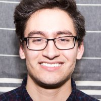

- Fire Ants Workshops
  - 07-09NOV (orig 24-26OCT) Kansas City
  - 06-08FEB? (orig 12-14DEC) Des Moine
  - 03-05APR Chicago
- New Application Ideas
  - Rourke - Discount Tires & OnQ Financial
  - Davenport - Analytics & Visualizations
  - Cohen - 2 Song Break (cloud foundry app with API to Spotify)
  - Goyette - Modernization of Tools (i.e. OpsConsole, CST)

## Administrivia (III)

- Around the Horn
  - Cohen - Discuss with JJ
  - Sweezy - sickness (gloom, agony, despair)
  - Nixon - learning the Google Play appp submission process. legal. Bat to search for court case. Also to provide legalese.
  - Mordi - parsing challenges. Investigating `rpart.utils
  - Goyette - interesting in jumping in and getting started.
  - Battles - Jira from Atlassian

## Application Flow / Architecture Overview

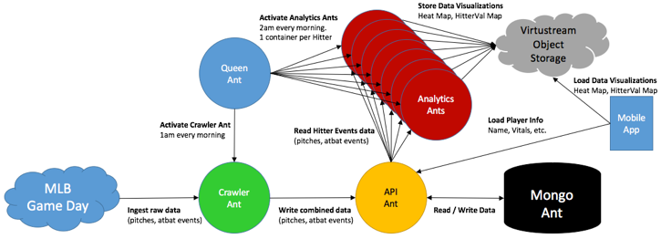

## Release 1.0 Progress

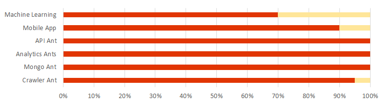

- **Mobile Ant** - updating head-shot URLs. Google Play, Apple Store submissions.
- **Machine Learning Ant** - challenges with parsing Classification Trees. Altuve. zone, p_type, away, 90% GOOD for a pitcher. nasty<60 85% BAD for pitcher
- **API Ant** - completed. Fields may be added for machine learning. PUT char string.
- **Analytics Ant** - completed. Dan to activate via cron.
- **Mongo Ant** - completed.
- **Crawler Ant** - scheduling

## Summary Notes from last Scrum

- Schedule update CRONS for Sundays at 2am.
- https://www.tiobe.com/tiobe-index/
- https://github.com/gliderlabs/logspout
- https://www.tddapps.com/2017/02/18/how-to-run-any-container-on-a-schedule/

## Summary Notes

- Bat to schedule introduction with Colin
- Bee and Bat to schedule machine learning with Colin
- Bat to provide legalese and court cases to Nix
- Nix to submit to Google Play
- Bat to update workshop dates in the calednar.